# Cone Development Differential Expression Analyses

Nicolas Delhomme & Veronika Nordal

2016-12-07

# 1 Setup

# 2 Environment

Set the working dir

```r
setwd("/mnt/picea/projects/spruce/onilsson/cone-development")
```

Libs

```r
suppressPackageStartupMessages(library(DESeq2))
suppressPackageStartupMessages(library(gplots))
suppressPackageStartupMessages(library(LSD))
suppressPackageStartupMessages(library(pander))
suppressPackageStartupMessages(library(RColorBrewer))
suppressPackageStartupMessages(library(scatterplot3d))
suppressPackageStartupMessages(library(VennDiagram))
```

Helper files

```r
suppressMessages(source("~/Git/UPSCb/src/R/densityPlot.R"))
suppressMessages(source("~/Git/UPSCb/src/R/plotMA.R"))
suppressMessages(source("~/Git/UPSCb/src/R/volcanoPlot.R"))
```

Load saved data

```r
load("analysis/DESeq2/deseq-sampling_time-tissue_type.rda")
vst <- read.csv("analysis/HTSeq/library-size-normalized_variance-stabilized_data.csv",
                row.names=1)
```

Setup graphics

```r
pal=brewer.pal(8,"Dark2")
mar <- par("mar")
```

# 3 Process

Differential Expression This fails because the matrix is not full rank, as not all interaction exists

```r
dds <- DESeq(dds)
```

This also fails because effects are confounded, e.g. P was only sequenced on 05-12

```r
design(dds) <- ~Sampling + Sex
dds <- DESeq(dds)
```

Plotting the information Clearly the O, P and S samples are date confounded, so they need to be removed for the time being

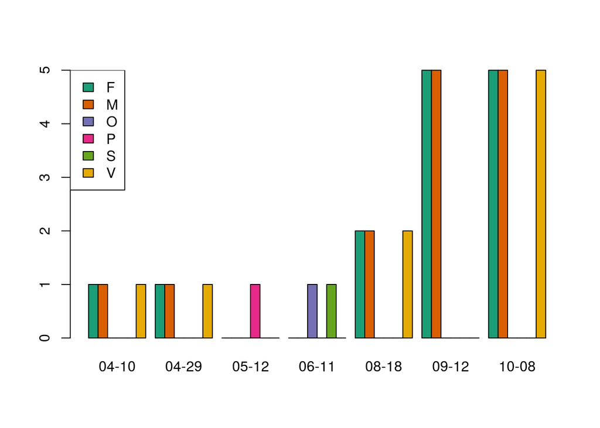

```r
barplot(sapply(split(colData(dds)$Sex,colData(dds)$Sampling),table),
        beside=TRUE,col=pal[1:nlevels(colData(dds)$Sex)])

legend("topleft",legend=levels(colData(dds)$Sex),
       fill=pal[1:nlevels(colData(dds)$Sex)])
```

Removing the O, P and S samples using their date

```r
dds.s <- dds[,!colData(dds)$Sampling %in% c("05-12","06-11")]
vst <- vst[,!colData(dds)$Sampling %in% c("05-12","06-11")]
```

and adjusting the factor

```r
dds.s$Sampling <- droplevels(dds.s$Sampling)
dds.s$Sex <- droplevels(dds.s$Sex)
```

The absence of V for the 09-12 date makes it impossible to get a full rank interaction matrix. However, looking at the biological QA heatmap and knowing that the meristem of the cones mature differently between sex, we can add a novel variable

```r
colData(dds.s)$Meristem <- factor(ifelse(colData(dds.s)$Sampling=="08-18",
                                  "1",
                                  ifelse(colData(dds.s)$Sampling
                                         %in% c("09-12","10-08"),
                                         ifelse(colData(dds.s)$Sex=="M",
                                         "3","2"),
                                    "4")))
```

Furthermore, we are not interested in late meristem samples

```r
dds.m <- dds.s[,colData(dds.s)$Meristem %in% c(1:3)]
vst <- vst[,colData(dds.s)$Meristem %in% c(1:3)]
dds.m$Sampling <- droplevels(dds.m$Sampling)
dds.m$Meristem <- droplevels(dds.m$Meristem)
design(dds.m) <- ~Meristem
```

Do the differential expression

```r
dds.m <- DESeq(dds.m)
```

```
## -- replacing outliers and refitting for 1178 genes
## -- DESeq argument 'minReplicatesForReplace' = 7
## -- original counts are preserved in counts(dds)
```

Dispersion Estimation

The dispersion estimation is adequate

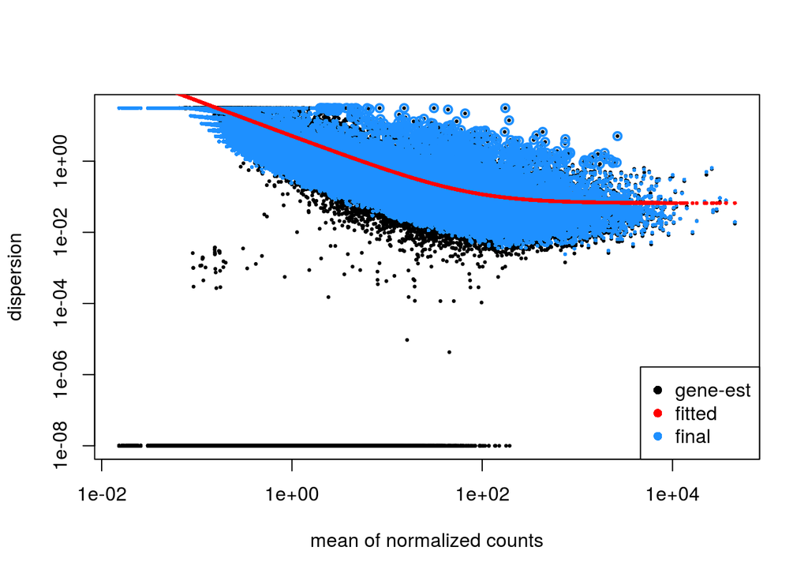

```r
plotDispEsts(dds.m)
```

Look at what contrasts are available

```r
resultsNames(dds.m)
```

```
## [1] "Intercept" "Meristem1" "Meristem2" "Meristem3"
```

```r
res <- results(dds.m,contrast=c("Meristem","2","3"))
```

assume a 1% FDR

```r
alpha=0.01
```

Plot the Median vs Average

There are many genes that appear differentially expressed at a 1% FDR cutoff The log2 fold-change range is relatively broad, with three extreme values

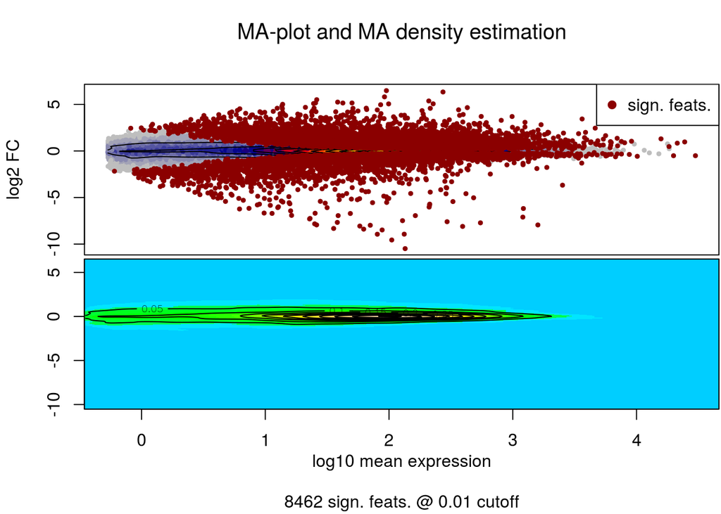

```r
plotMA(res,alpha)
```

Plot the log odds vs. log2 fold change

The volcano plot shows the same results as the MA plot; a large number of genes show significant fold-changes

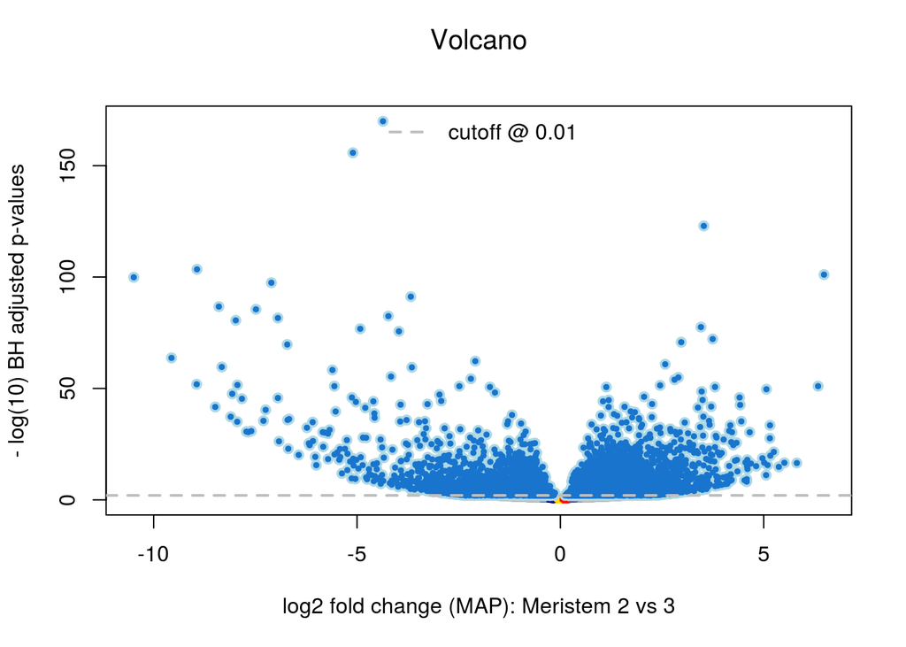

```r
volcanoPlot(res,alpha=alpha)
```

Plot the adjusted p-value histogram

Which is almost evenly distributed, with an enrichment for lower p-values (more significant)

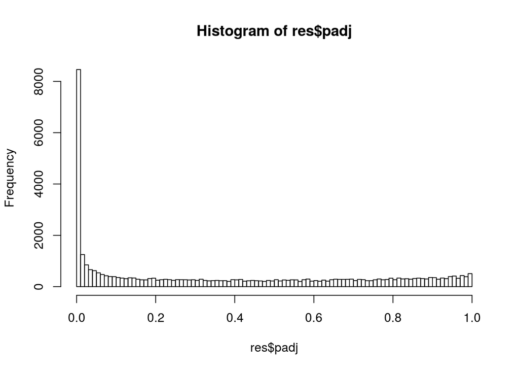

```r
hist(res$padj,breaks=seq(0,1,.01))
```

Select genes below alpha

Note the cutoff selection on the log fold change is motivated by the Schurch et al. RNA, 2016 publication

```r
sel <- res$padj<alpha & !is.na(res$padj) & abs(res$log2FoldChange) >= 0.5
sprintf("There are %s genes differentially expressed at a %s cutoff",
        sum(sel),alpha)
```

```
## [1] "There are 6601 genes differentially expressed at a 0.01 cutoff"
```

```r
pander(table(sign(res[sel,"log2FoldChange"])))
```

| -1 | 1 |
| --- | --- |
| 2671 | 3930 |

```r
# #' Write them out
write(sub("\\.0$","",rownames(res)[sel]),
       file=file.path("analysis/DESeq2",
                      "Meristem3-vs-Meristem2_one-percent-FDR-cutoff_significant-genes.txt"))

write(sub("\\.0$","",rownames(res)[sel & sign(res$log2FoldChange)==1]),
      file=file.path("analysis/DESeq2",
                     "m3-vs-m2-Meristem2-up-regulated_one-percent-FDR-cutoff_significant-genes.txt"))

write(sub("\\.0$","",rownames(res)[sel & sign(res$log2FoldChange) == -1]),
      file=file.path("analysis/DESeq2",
                     "m3-vs-m2-Meristem3-up-regulated_one-percent-FDR-cutoff_significant-genes.txt"))

write.csv(as.data.frame(res),
          file=file.path("analysis/DESeq2",
                         "Meristem3_vs_meristem2.csv"))

m3.vs.m2 <- rownames(res)[sel]
```

#### 3.1.0.1 Cluster the VST expression of the genotype genes

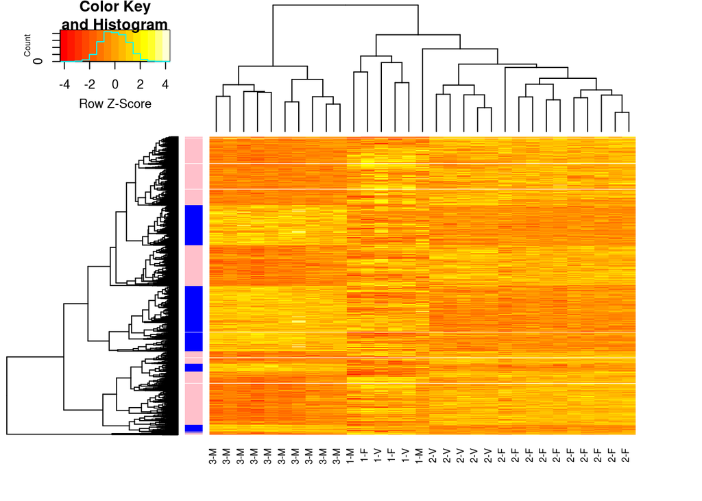

```r
heatmap.2(as.matrix(vst[rownames(vst) %in% m3.vs.m2,]),
          scale="row",labRow=NA,trace="none",
          RowSideColors=ifelse(sign(res[sel,"log2FoldChange"])==-1,
                               "blue",
                               "pink"),
          labCol=paste(colData(dds.m)$Meristem,colData(dds.m)$Sex,sep="-"))
```

```r
res <- results(dds.m,contrast=c("Meristem","1","3"))
```

assume a 1% FDR

```r
alpha=0.01
```

There are many genes that appear differentially expressed. The log2 fold-change range is relatively broad, with two extreme positive values

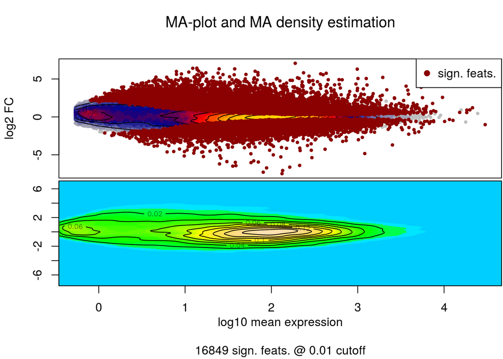

```r
plotMA(res,alpha)
```

Plot the log odds vs. log2 fold change

The volcano plot shows the same results as the MA plot; a large number of genes show significant fold-changes

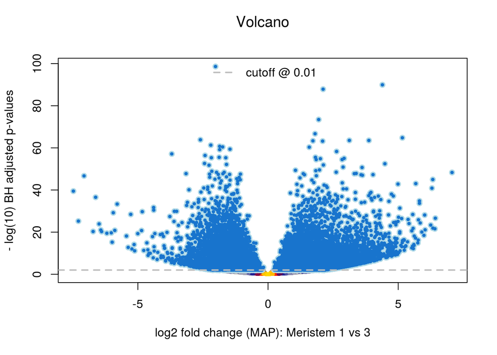

```r
volcanoPlot(res,alpha=alpha)
```

Plot the adjusted p-value histogram

Which is almost evenly distributed, with an enrichment for lower p-values (most significant)

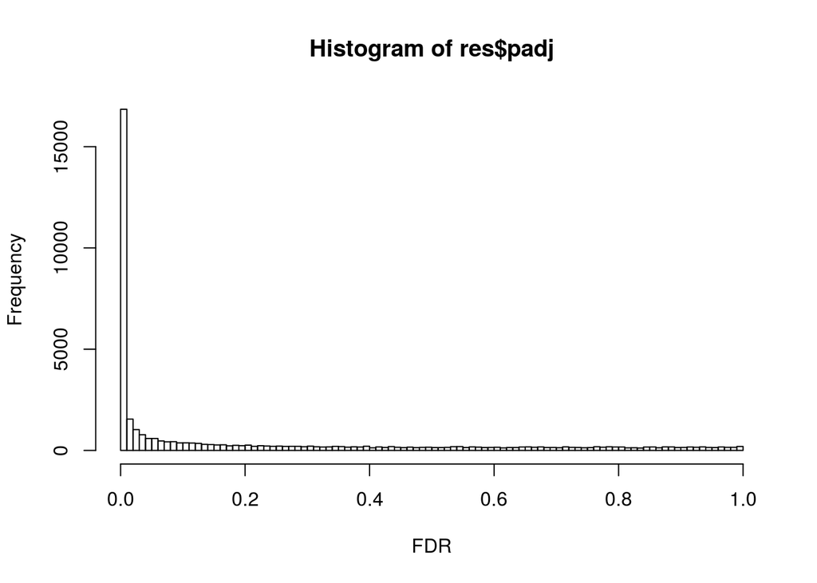

```r
hist(res$padj,breaks=seq(0,1,.01),xlab="FDR")
```

Select genes below alpha

Note the 0.5 cutoff on the log fold change is motivated by the Schurch et al. RNA, 2016 publication

```r
sel <- res$padj<alpha & !is.na(res$padj) & abs(res$log2FoldChange) >= 0.5
sprintf("There are %s genes differentially expressed at a %s cutoff",
        sum(sel),alpha)
```

```
## [1] "There are 15880 genes differentially expressed at a 0.01 cutoff"
```

```r
pander(table(sign(res[sel,"log2FoldChange"])))
```

| -1 | 1 |
| --- | --- |
| 7641 | 8239 |

Write them out

```r
write(sub("\\.0$","",rownames(res)[sel]),
      file=file.path("analysis/DESeq2",
                     "Meristem3-vs-Meristem1_one-percent-FDR-cutoff_significant-genes.txt"))

write(sub("\\.0$","",rownames(res)[sel & sign(res$log2FoldChange)==1]),
      file=file.path("analysis/DESeq2",
                     "m3-vs-m1-Meristem1-up-regulated_one-percent-FDR-cutoff_significant-genes.txt"))

write(sub("\\.0$","",rownames(res)[sel & sign(res$log2FoldChange) == -1]),
      file=file.path("analysis/DESeq2",
                     "m3-vs-m1-Meristem3-up-regulated_one-percent-FDR-cutoff_significant-genes.txt"))

write.csv(as.data.frame(res),
          file=file.path("analysis/DESeq2",
                         "Meristem3_vs_meristem1.csv"))

m3.vs.m1 <- rownames(res)[sel]
```

#### 3.2.0.1 Cluster the VST expression of the genotype genes

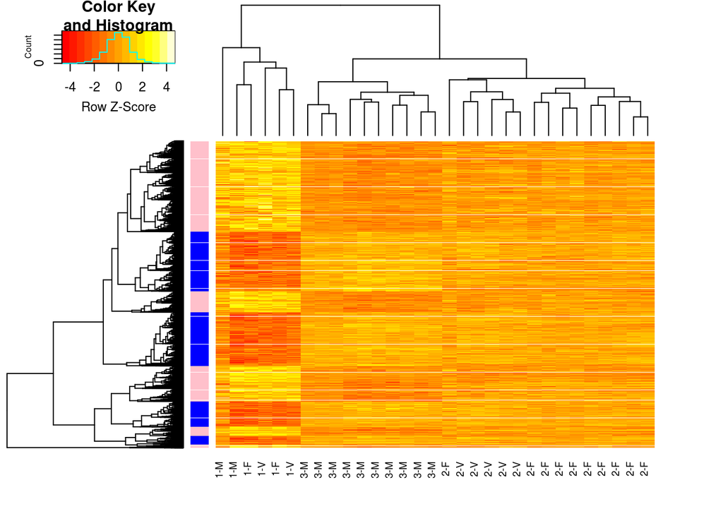

```r
heatmap.2(as.matrix(vst[rownames(vst) %in% m3.vs.m1,]),
          scale="row",labRow=NA,trace="none",
          RowSideColors=ifelse(sign(res[sel,"log2FoldChange"])==-1,
                               "blue",
                               "pink"),
          labCol=paste(colData(dds.m)$Meristem,colData(dds.m)$Sex,sep="-"))
```

```r
res <- results(dds.m,contrast=c("Meristem","1","2"))
```

assume a 1% FDR

```r
alpha=0.01
```

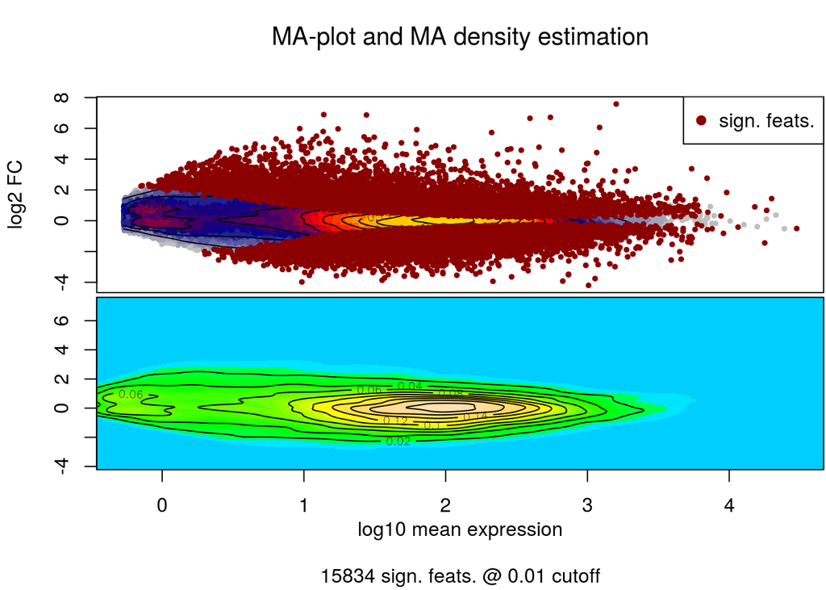

```r
plotMA(res,alpha)
```

Plot the log odds vs. log2 fold change

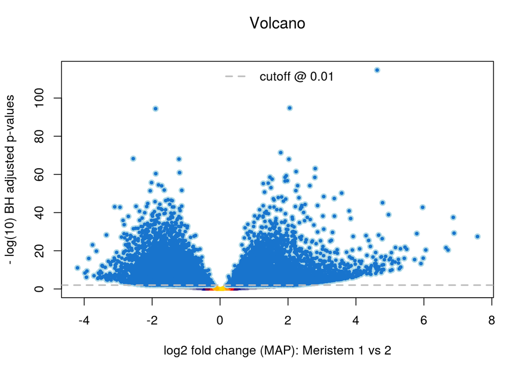

```r
volcanoPlot(res,alpha=alpha)
```

Plot the adjusted p-value histogram

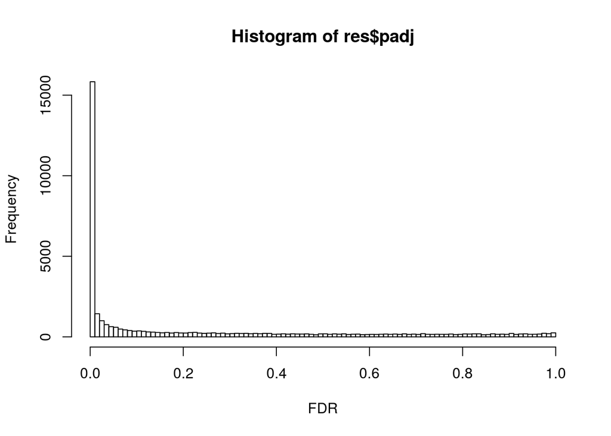

```r
hist(res$padj,breaks=seq(0,1,.01),xlab="FDR")
```

Select genes below alpha

Note the 0.5 cutoff on the log fold change is motivated by the Schurch et al. RNA, 2016 publication

```r
sel <- res$padj<alpha & !is.na(res$padj) & abs(res$log2FoldChange) >= 0.5
sprintf("There are %s genes differentially expressed at a %s cutoff",
        sum(sel),alpha)
```

```
## [1] "There are 14689 genes differentially expressed at a 0.01 cutoff"
```

Almost evenly distributed

```r
pander(table(sign(res[sel,"log2FoldChange"])))
```

| -1 | 1 |
| --- | --- |
| 7623 | 7066 |

Write them out

```r
write(sub("\\.0$","",rownames(res)[sel]),
      file=file.path("analysis/DESeq2",
                     "Meristem2-vs-Meristem1_one-percent-FDR-cutoff_significant-genes.txt"))

write(sub("\\.0$","",rownames(res)[sel & sign(res$log2FoldChange)==1]),
      file=file.path("analysis/DESeq2",
                     "m2-vs-m1-Meristem2-up-regulated_one-percent-FDR-cutoff_significant-genes.txt"))

write(sub("\\.0$","",rownames(res)[sel & sign(res$log2FoldChange) == -1]),
      file=file.path("analysis/DESeq2",
                     "m2-vs-m1-Meristem1-down-regulated_one-percent-FDR-cutoff_significant-genes.txt"))

write.csv(as.data.frame(res),
          file=file.path("analysis/DESeq2",
                         "Meristem2_vs_Meristem1.csv"))

m2.vs.m1 <- rownames(res)[sel]
```

#### 3.3.0.1 Cluster the VST expression of the interaction genes

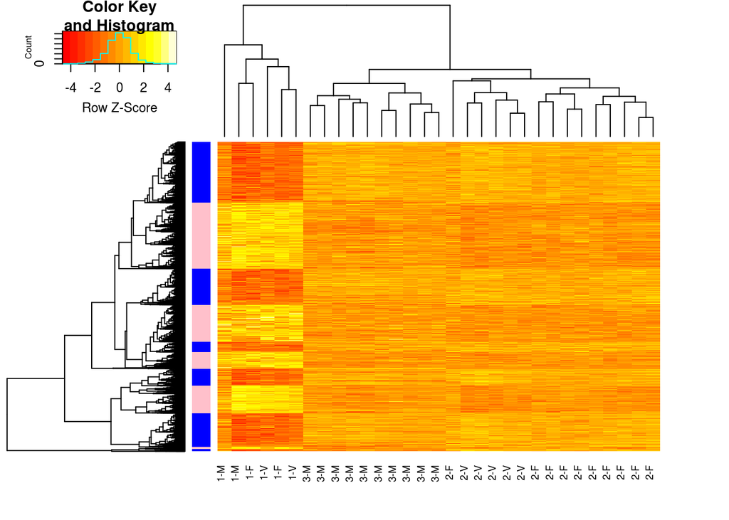

```r
heatmap.2(as.matrix(vst[rownames(vst) %in% m2.vs.m1,]),
          scale="row",labRow=NA,trace="none",
          RowSideColors=ifelse(sign(res[sel,"log2FoldChange"])==-1,
                               "blue",
                               "pink"),
          labCol=paste(colData(dds.m)$Meristem,colData(dds.m)$Sex,sep="-"))
```

### 3.3.1 Check the overlap of the three sets

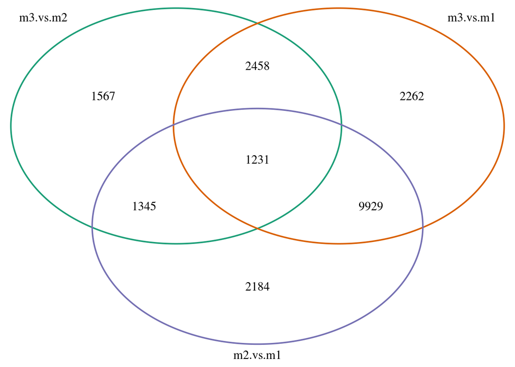

```r
plot.new()
grid.draw(venn.diagram(list(
  m3.vs.m2=m3.vs.m2,
  m3.vs.m1=m3.vs.m1,
  m2.vs.m1=m2.vs.m1),
  filename=NULL,
  col=pal[1:3],
  category.names=c("m3.vs.m2","m3.vs.m1","m2.vs.m1")))
```

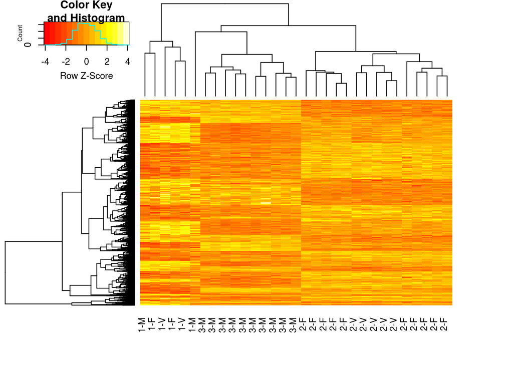

```r
heatmap.2(as.matrix(vst[rownames(vst) %in% intersect(m3.vs.m2,m2.vs.m1),]),
          scale="row",labRow=NA,trace="none",
          labCol=paste(colData(dds.m)$Meristem,colData(dds.m)$Sex,sep="-"))
```

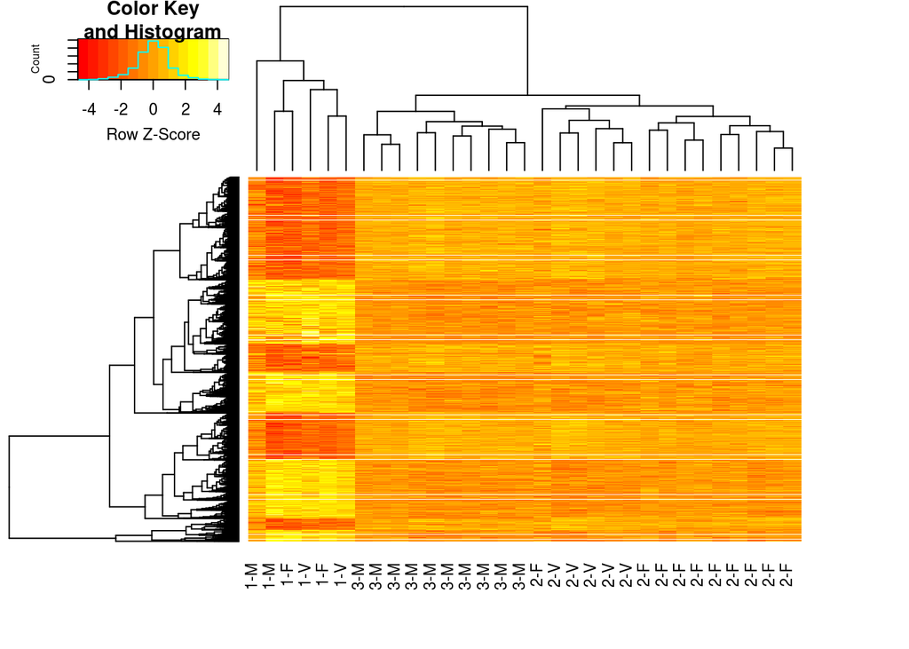

```r
heatmap.2(as.matrix(vst[rownames(vst) %in% intersect(m3.vs.m1,m2.vs.m1),]),
          scale="row",labRow=NA,trace="none",
          labCol=paste(colData(dds.m)$Meristem,colData(dds.m)$Sex,sep="-"))
```

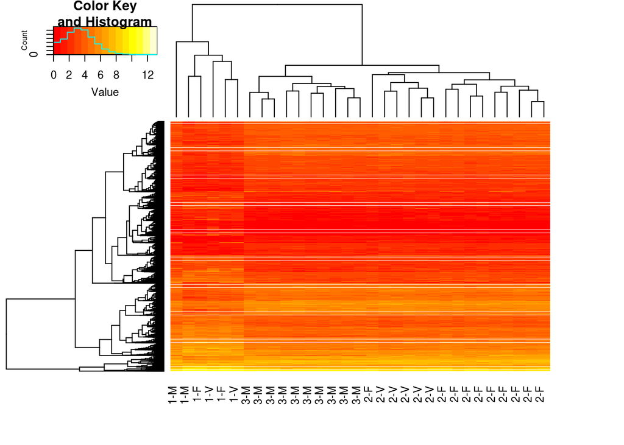

```r
heatmap.2(as.matrix(vst[rownames(vst) %in% intersect(m3.vs.m1,m2.vs.m1),]),
          labRow=NA,trace="none",
          labCol=paste(colData(dds.m)$Meristem,colData(dds.m)$Sex,sep="-"))
```

# 4 Conclusion